# Analysing Stock Market Movement During COVID-19

Coronavirus disease 2019 (COVID-19) is a respiratory illness that can spread from one person to another. This infectious disease is caused by a novel coronavirus that was first identified during an investigation into an outbreak in Wuhan, China, in December 2019. On March 11th, 2020 WHO has characterized COVID-19 as a pandemic as the number of cases that have been detected in most countries worldwide and community spread is keep on increasing.

Due to COVID-19, many sectors have been deeply affected including retailers, financial services, travel and hospitality, airline, event management and many more. In this assignment, we would like to see how COVID-19 affects the stock market movement in a few selected sectors that we have chosen. We are using Yahoo Finance in assessing the stock market movement during COVID-19.

```python
#Install pandas datareader

!pip install pandas_datareader==0.7.0


#Import pandas datareader

import pandas_datareader
pandas_datareader.__version__

import pandas as pd
from pandas_datareader import data


# Install the yfinance

!pip install yfinance

import yfinance as yf
```

```python
#Set the start date of the COVID-19 outbreak and the current date

start_date = '2019-12-31'
current_date = '2020-03-12'
```

## Sector 1 : Healthcare

In this sector, we investigate 5 companies namely Johnson & Johnson (JNJ), Merk & Co. Inc (MRK), Abbott Laboratories (ABT), Moderna, Inc. (MRNA) and Vir Biotechnology (VIR).

```python
#Setting for multiple tickers in health sector

tickers_health = ('JNJ', 'MRK', 'ABT', 'MRNA', 'VIR')
```

```python
#Get the data from multiple tickers

data_hlth = yf.download(tickers_health,
 start_date,
 current_date)

data_hlth.head()
```

```
[*********************100%***********************]  5 of 5 completed
```

| Date | Adj Close ABT | Adj Close JNJ | Adj Close MRK | Adj Close MRNA | Adj Close VIR | Close ABT | Close JNJ | Close MRK | Close MRNA | Close VIR | ... | Open ABT | Open JNJ | Open MRK | Open MRNA | Open VIR | Volume ABT | Volume JNJ | Volume MRK | Volume MRNA | Volume VIR |
| --- | --- | --- | --- | --- | --- | --- | --- | --- | --- | --- | --- | --- | --- | --- | --- | --- | --- | --- | --- | --- | --- |
| 2019-12-30 | 86.432899 | 144.379349 | 90.284149 | 19.049999 | 12.120 | 86.800003 | 145.300003 | 91.029999 | 19.049999 | 12.120 | ... | 87.519997 | 145.779999 | 91.529999 | 19.540001 | 12.41 | 2706100 | 2923300 | 3752800 | 1183300 | 106400 |
| 2019-12-31 | 86.492645 | 144.945724 | 90.204803 | 19.559999 | 12.575 | 86.860001 | 145.869995 | 90.949997 | 19.559999 | 12.575 | ... | 86.500000 | 145.100006 | 90.919998 | 18.959999 | 12.14 | 3261100 | 4435000 | 4495000 | 1112400 | 241400 |
| 2020-01-02 | 86.582260 | 145.045090 | 91.285881 | 19.230000 | 12.150 | 86.949997 | 145.970001 | 92.040001 | 19.230000 | 12.150 | ... | 86.059998 | 145.869995 | 91.080002 | 19.570000 | 12.56 | 4969000 | 5777000 | 7873500 | 1233600 | 142200 |
| 2020-01-03 | 85.526741 | 143.365799 | 90.502350 | 18.889999 | 12.040 | 85.889999 | 144.279999 | 91.250000 | 18.889999 | 12.040 | ... | 85.750000 | 143.500000 | 90.680000 | 19.020000 | 12.20 | 4747000 | 5752400 | 5633300 | 1751000 | 103700 |
| 2020-01-06 | 85.974838 | 143.186951 | 90.889153 | 18.129999 | 12.190 | 86.339996 | 144.100006 | 91.639999 | 18.129999 | 12.190 | ... | 85.620003 | 144.000000 | 91.230003 | 18.700001 | 12.13 | 5631700 | 7731300 | 7178400 | 1606500 | 89500 |

5 rows × 30 columns

```python
df_datahealth=pd.DataFrame(data_hlth)
df_datahealth
```

[output not shown]

50 rows × 30 columns

```
<function matplotlib.pyplot.show(*args, **kw)>
```

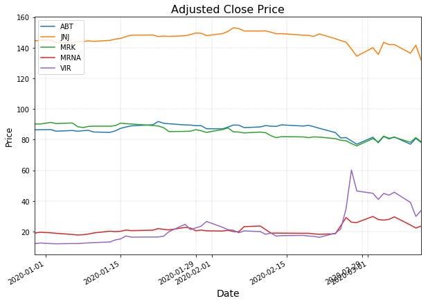

```python
#Visualisation of the adjusted close price data for all tickers

import matplotlib.pyplot as plt
%matplotlib inline

data_hlth['Adj Close'].plot(figsize=(10,7))
plt.title("Adjusted Close Price", fontsize=16)
plt.ylabel('Price', fontsize=12)
plt.xlabel('Date', fontsize=14)
plt.grid(which="major", color='k', linestyle='-.', linewidth=0.1)
plt.show
```

```python
#Group the data by tickers

dataHT = yf.download(tickers_health,
 start_date,
 current_date,
 group_by="tickers")

dataHT.head()
```

```
[*********************100%***********************]  5 of 5 completed
```

| Date | VIR Open | VIR High | VIR Low | VIR Close | VIR Adj Close | VIR Volume | ABT Open | ABT High | ABT Low | ABT Close | ... | MRK Low | MRK Close | MRK Adj Close | MRK Volume | JNJ Open | JNJ High | JNJ Low | JNJ Close | JNJ Adj Close | JNJ Volume |
| --- | --- | --- | --- | --- | --- | --- | --- | --- | --- | --- | --- | --- | --- | --- | --- | --- | --- | --- | --- | --- | --- |
| 2019-12-30 | 12.41 | 12.638 | 12.08 | 12.120 | 12.120 | 106400 | 87.519997 | 87.790001 | 86.610001 | 86.800003 | ... | 90.730003 | 91.029999 | 90.284149 | 3752800 | 145.779999 | 146.199997 | 145.029999 | 145.300003 | 144.379349 | 2923300 |
| 2019-12-31 | 12.14 | 12.980 | 12.01 | 12.575 | 12.575 | 241400 | 86.500000 | 86.989998 | 86.269997 | 86.860001 | ... | 90.440002 | 90.949997 | 90.204803 | 4495000 | 145.100006 | 146.009995 | 144.779999 | 145.869995 | 144.945724 | 4435000 |
| 2020-01-02 | 12.56 | 12.942 | 12.01 | 12.150 | 12.150 | 142200 | 86.059998 | 86.959999 | 85.800003 | 86.949997 | ... | 90.370003 | 92.040001 | 91.285881 | 7873500 | 145.869995 | 146.020004 | 145.080002 | 145.970001 | 145.045090 | 5777000 |
| 2020-01-03 | 12.20 | 12.380 | 12.00 | 12.040 | 12.040 | 103700 | 85.750000 | 86.669998 | 85.589996 | 85.889999 | ... | 90.510002 | 91.250000 | 90.502350 | 5633300 | 143.500000 | 145.369995 | 143.000000 | 144.279999 | 143.365799 | 5752400 |
| 2020-01-06 | 12.13 | 12.310 | 12.04 | 12.190 | 12.190 | 89500 | 85.620003 | 86.360001 | 85.209999 | 86.339996 | ... | 90.989998 | 91.639999 | 90.889153 | 7178400 | 144.000000 | 144.199997 | 142.850006 | 144.100006 | 143.186951 | 7731300 |

5 rows × 30 columns

```python
df_dataHT=pd.DataFrame(dataHT)
df_dataHT
```

[output not shown]

50 rows × 30 columns

```python
#Convert data to csv file

## Data by stock movement
data_hlth.to_csv("C:/Users/ASUS/Desktop/DataHealthSector_All.csv")

## Data grouped by tickers
dataHT.to_csv("C:/Users/ASUS/Desktop/DataHealthSector_byTickers.csv")
```

## Sector 2 : Industrials

Meanwhile, in industrials sector, we pick these 5 companies namely Honeywell International Inc. (HON), Union Pacific Corporation (UNP), The Boeing Company (BA), Thomson Reuters Corporation (TRI) and Delta Air Lines, Inc. (DAL).

```python
#Setting for multiple tickers in industrials sector

tickers_industrials = ('HON', 'UNP', 'BA', 'TRI', 'DAL')
```

```python
#Get the data from multiple tickers in industrials

data_ind = yf.download(tickers_industrials,
 start_date,
 current_date)

data_ind.head()
```

```
[*********************100%***********************]  5 of 5 completed
```

| Date | Adj Close BA | Adj Close DAL | Adj Close HON | Adj Close TRI | Adj Close UNP | Close BA | Close DAL | Close HON | Close TRI | Close UNP | ... | Open BA | Open DAL | Open HON | Open TRI | Open UNP | Volume BA | Volume DAL | Volume HON | Volume TRI | Volume UNP |
| --- | --- | --- | --- | --- | --- | --- | --- | --- | --- | --- | --- | --- | --- | --- | --- | --- | --- | --- | --- | --- | --- |
| 2019-12-30 | 324.469513 | 58.257912 | 175.470261 | 71.143227 | 179.095734 | 326.399994 | 58.660000 | 176.419998 | 71.489998 | 180.149994 | ... | 330.500000 | 59.250000 | 176.559998 | 71.860001 | 181.149994 | 4525500 | 3779300 | 1670100 | 289800 | 1493000 |
| 2019-12-31 | 323.833313 | 58.079147 | 176.047134 | 71.252693 | 179.731979 | 325.760010 | 58.480000 | 177.000000 | 71.599998 | 180.789993 | ... | 325.410004 | 58.490002 | 176.460007 | 71.379997 | 179.960007 | 4958800 | 2917300 | 1728900 | 312900 | 1588800 |
| 2020-01-02 | 331.348572 | 58.635307 | 179.816727 | 71.819931 | 181.203323 | 333.320007 | 59.040001 | 180.789993 | 72.169998 | 182.270004 | ... | 328.549988 | 58.930000 | 177.500000 | 71.610001 | 180.949997 | 4544400 | 4459200 | 2857400 | 293200 | 2444800 |
| 2020-01-03 | 330.791901 | 57.662025 | 177.897125 | 72.247841 | 179.920868 | 332.760010 | 58.060001 | 178.860001 | 72.599998 | 180.979996 | ... | 330.630005 | 57.500000 | 178.339996 | 71.620003 | 179.539993 | 3875900 | 9078100 | 2805200 | 286500 | 2344200 |
| 2020-01-06 | 331.766083 | 57.264767 | 176.554382 | 72.994202 | 178.379944 | 333.739990 | 57.660000 | 177.509995 | 73.349998 | 179.429993 | ... | 329.299988 | 56.990002 | 177.839996 | 72.300003 | 179.699997 | 5355000 | 5504300 | 3277900 | 454300 | 3142500 |

5 rows × 30 columns

```python
df_dataindustrials=pd.DataFrame(data_ind)
df_dataindustrials
```

[output not shown]

50 rows × 30 columns

```
<function matplotlib.pyplot.show(*args, **kw)>
```

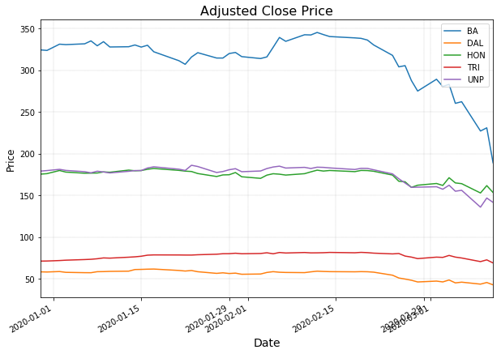

```python
#Visualisation of the adjusted close price data for all tickers

import matplotlib.pyplot as plt
%matplotlib inline

data_ind['Adj Close'].plot(figsize=(10,7))
plt.title("Adjusted Close Price", fontsize=16)
plt.ylabel('Price', fontsize=12)
plt.xlabel('Date', fontsize=14)
plt.grid(which="major", color='k', linestyle='-.', linewidth=0.1)
plt.show
```

```python
#Group the data by tickers

dataIT = yf.download(tickers_industrials,
 start_date,
 current_date,
 group_by="tickers")

dataIT.head()
```

```
[*********************100%***********************]  5 of 5 completed
```

| Date | BA Open | BA High | BA Low | BA Close | BA Adj Close | BA Volume | UNP Open | UNP High | UNP Low | UNP Close | ... | HON Low | HON Close | HON Adj Close | HON Volume | DAL Open | DAL High | DAL Low | DAL Close | DAL Adj Close | DAL Volume |
| --- | --- | --- | --- | --- | --- | --- | --- | --- | --- | --- | --- | --- | --- | --- | --- | --- | --- | --- | --- | --- | --- |
| 2019-12-30 | 330.500000 | 330.630005 | 325.709991 | 326.399994 | 324.469513 | 4525500 | 181.149994 | 181.380005 | 179.600006 | 180.149994 | ... | 175.759995 | 176.419998 | 175.470261 | 1670100 | 59.250000 | 59.299999 | 58.240002 | 58.660000 | 58.257912 | 3779300 |
| 2019-12-31 | 325.410004 | 326.570007 | 323.320007 | 325.760010 | 323.833313 | 4958800 | 179.960007 | 181.259995 | 179.539993 | 180.789993 | ... | 175.460007 | 177.000000 | 176.047134 | 1728900 | 58.490002 | 58.730000 | 58.340000 | 58.480000 | 58.079147 | 2917300 |
| 2020-01-02 | 328.549988 | 333.350006 | 327.700012 | 333.320007 | 331.348572 | 4544400 | 180.949997 | 182.380005 | 179.970001 | 182.270004 | ... | 177.139999 | 180.789993 | 179.816727 | 2857400 | 58.930000 | 59.389999 | 58.450001 | 59.040001 | 58.635307 | 4459200 |
| 2020-01-03 | 330.630005 | 334.890015 | 330.299988 | 332.760010 | 330.791901 | 3875900 | 179.539993 | 181.190002 | 178.289993 | 180.979996 | ... | 177.410004 | 178.860001 | 177.897125 | 2805200 | 57.500000 | 58.119999 | 56.910000 | 58.060001 | 57.662025 | 9078100 |
| 2020-01-06 | 329.299988 | 334.859985 | 327.880005 | 333.739990 | 331.766083 | 5355000 | 179.699997 | 180.080002 | 177.940002 | 179.429993 | ... | 176.929993 | 177.509995 | 176.554382 | 3277900 | 56.990002 | 57.759998 | 56.660000 | 57.660000 | 57.264767 | 5504300 |

5 rows × 30 columns

```python
df_dataIT=pd.DataFrame(dataIT)
df_dataIT
```

[output not shown]

50 rows × 30 columns

```python
#Convert data to csv file

## Data by stock movement
data_ind.to_csv("C:/Users/ASUS/Desktop/DataIndustrialsSector_All.csv")

## Data grouped by tickers
dataIT.to_csv("C:/Users/ASUS/Desktop/DataIndustrialsSector_byTickers.csv")
```